# Analysis of the U.S. National Oceanic and Atmospheric Administration’s (NOAA) Storm Database

Diane Clow

June 14, 2015

Reproducible Research

### Introduction

This analysis was produced for the second project in the Reproducible Research class offered on Coursera. In this project, the Storm Datable maintained by NOAA was analysed looking for information on: 1) What events are most harmful to humans, and 2) What events have the greated economical impact.

### Importing Data

The data is from the NOAA Storm Database and contains data from 1950 to November 2011. The data has 902297 observations and 37 variables.

```r
StormData <- read.csv("repdata-data-StormData.csv.bz2")
library(ggplot2)
```

The column names in the data set are listed below

```r
colnames(StormData)
```

```
##  [1] "STATE__"    "BGN_DATE"   "BGN_TIME"   "TIME_ZONE"  "COUNTY"
##  [6] "COUNTYNAME" "STATE"      "EVTYPE"     "BGN_RANGE"  "BGN_AZI"
## [11] "BGN_LOCATI" "END_DATE"   "END_TIME"   "COUNTY_END" "COUNTYENDN"
## [16] "END_RANGE"  "END_AZI"    "END_LOCATI" "LENGTH"     "WIDTH"
## [21] "F"          "MAG"        "FATALITIES" "INJURIES"   "PROPDMG"
## [26] "PROPDMGEXP" "CROPDMG"    "CROPDMGEXP" "WFO"        "STATEOFFIC"
## [31] "ZONENAMES"  "LATITUDE"   "LONGITUDE"  "LATITUDE_E" "LONGITUDE_"
## [36] "REMARKS"    "REFNUM"
```

### Question 1

Across the United States, which types of events (as indicated in the EVTYPE variable) are most harmful with respect to population health?

To answer this question, first identify which variables will be used. Reading the different column names, “FATALITIES” and “INJURIES”. Seemed the most usefuel. Using the aggregate function, the total injuries and fatalities were calculated for each event type.

```r
fatalites <- aggregate(FATALITIES ~ EVTYPE, StormData, sum)
injuries <- aggregate(INJURIES ~ EVTYPE, StormData, sum)
```

Then the totals were reduced to the top 5 for both fatalites and injuries.

```r
fatal <- subset(fatalites, fatalites$FATALITIES > 600)
injury <- subset(injuries, injuries$INJURIES > 5000)
```

```r
harm <- merge(fatal, injury, by = "EVTYPE")
as.character(harm$EVTYPE)
```

```
## [1] "EXCESSIVE HEAT" "LIGHTNING"      "TORNADO"
```

```r
harm2 <- harm[order(harm$FATALITIES, decreasing = TRUE), ]
harm2
```

```
##           EVTYPE FATALITIES INJURIES
## 3        TORNADO       5633    91346
## 1 EXCESSIVE HEAT       1903     6525
## 2      LIGHTNING        816     5230
```

The below code modifys and combines the injury and fatal data frames, keeping track of which came from which. They are then combined into one data frame, plot_data (shown below), and that is plotted in a bar chart. There are a couple columns that only have one color. This means that while the event had enough of either injuries or fatalities to show up for one, they didn’t have enough to show up for the other. Looking at the chart below it is very clear that Tornados have both the largest number of fatalities and injuries by a landslide.

```r
type <- c("INJURIES", "INJURIES", "INJURIES", "INJURIES", "INJURIES")
injury1 <- cbind(injury, type)
type <- c("FATALITIES", "FATALITIES", "FATALITIES", "FATALITIES", "FATALITIES")
fatal1 <- cbind(fatal, type)
colnames(injury1) <- c("EVTYPE", "number", "type")
colnames(fatal1) <- c("EVTYPE", "number", "type")
plot_data <- rbind(injury1, fatal1)
plot_data
```

```
##              EVTYPE number       type
## 130  EXCESSIVE HEAT   6525   INJURIES
## 170           FLOOD   6789   INJURIES
## 464       LIGHTNING   5230   INJURIES
## 834         TORNADO  91346   INJURIES
## 856       TSTM WIND   6957   INJURIES
## 1301 EXCESSIVE HEAT   1903 FATALITIES
## 153     FLASH FLOOD    978 FATALITIES
## 275            HEAT    937 FATALITIES
## 4641      LIGHTNING    816 FATALITIES
## 8341        TORNADO   5633 FATALITIES
```

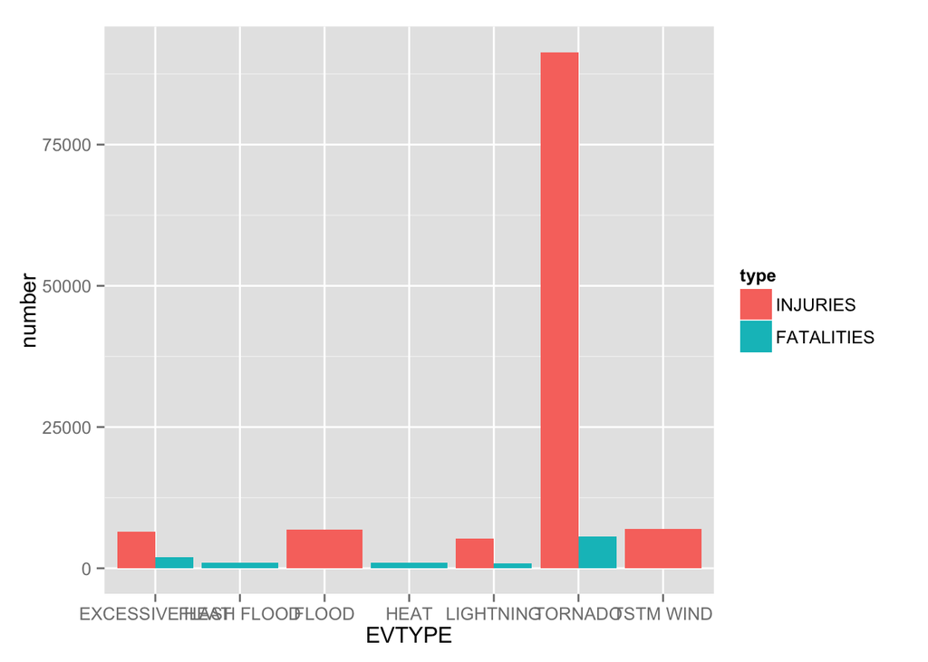

```r
qplot(x=EVTYPE, y=number, fill=type,
      data=plot_data, geom="bar", stat="identity",
      position="dodge")
```

### Question 2

Across the United States, which types of events have the greatest economic consequences?